# Frequentist and Bayesian Logistic Regression for Loan Repayment Analysis

# To Start

In this section, we want to analyze factors associated with loan repayment, so we are performing our analyses on the `loans.csv` data set. The statistical method we would use here is regression. Regression analysis is a predictive modelling technique that analyzes the relation between the dependent variable(s) and the independent variable(s) in a dataset. There are many types of regressions, and which one(s) to use depends upon a number of factors: the type of dependent variable, the number of independent variables, the pattern of dependent vs. independent variables, the shape of the regression line, etc. We will decide which type of regression to use after we dive deeper into our data.

First, we read the dataset into our R environment:

```r
loans <- read.csv("data/loans.csv")
```

Next, in order to perform our statistical analysis, we load all the packages needed using the `library()` function (in practice, which packages to use will be decided as you proceed with your analyses, rather than determined before starting):

```r
library(tidyverse)
library(loo)
library(countrycode)
library(broom)
library(kableExtra)
library(pROC)
library(rstanarm)
library(bayesplot)
```

There are eight core $\texttt{Tidyverse}$ packages namely $\texttt{ggplot2}$, $\texttt{dplyr}$, $\texttt{tidyr}$, $\texttt{readr}$, $\texttt{purrr}$, $\texttt{tibble}$, $\texttt{stringr}$, and $\texttt{forcats}$. In our analysis we are using $\texttt{dplyr}$ for data manipulations and $\texttt{ggplot2}$ for graphics. The $\texttt{loo}$ package allows us to compute efficient approximate leave-one-out cross-validation for fitted Bayesian models. $\texttt{pROC}$ is for displaying and analyzing ROC curves. $\texttt{rstanarm}$ is an appendage to the $\texttt{rstan}$ package, the R interface to Stan which features an expressive probabilistic programming language for specifying Bayesian models backed by extensive math and algorithm libraries to support automated computation. The $\texttt{bayesplot}$ package offers a variety of plots of posterior draws, visual MCMC diagnostics, and graphical posterior predictive checkings. Packages $\texttt{broom}$ and $\texttt{kableExtra}$ are used here to display messy output of models into clear tables.

# Logistic Regression

The response of interest is the loan repayment status, recorded in the `status` column of the `loans` data set. It is a categorical variable with 8 levels: “paid”, “refunded”, “defaulted”, “in_repayment”, “expired”, “inactive”, “fundraising”, and “funded”. Intuitively, for such a categorical response variable, one appropriate model would be a multinomial logistic regression which allows for more than two categories of the response variable. However, the interpretation of results is not as straightforward in such a model - and since the prompt is explicitly concerned with loan default, a more interpretable model would be one which dichotomizes the data to contrast defaulted and non-defaulted loans.

To achieve this, we restrict the dataset to completed loans, which are either repaid or not repaid. With a binary response variable, we can utilize a binary logistic regression. (We are not using a linear regression because it can generates predictions larger than 1 or smaller than 0 which are not sensible for classification since the true probability must fall between 0 and 1; also, linear regression assumes normal errors, which is not the case for a Bernoulli variable).

The logistic regression model is an example of a broad class of models known as generalized linear models (GLM). GLM’s extend ordinary least squares regression to response variables from arbitrary distributions through the use of a link function; instead of the response varying linearly with the covariates, its link function does. In this case, our response is a binary variable and so the Bernoulli model is appropriate. The Bernoulli distribution is a discrete probability distribution of a random variable which takes the value 1 with probability $p$ and the value 0 with probability $q=1-p$.The likelihood for one observation $y$ can be written as a Bernoulli PMF over possible outcomes $k$:
$$\begin{equation}
f(k;p) =
\left\{
\begin{array}{cc}
p & \mathrm{if\ } k=1 \\
1-p & \mathrm{if\ } k=0 \\
\end{array}
\right.
\end{equation},$$

The two most common link functions used for binomial GLMs are the logit and probit functions. For binary outcomes a common choice is the *logit link.* The logit link converts probabilities to log odds, and therefore the model coefficients can be easily interpreted in terms of odds ratios. When the logit link function is used the model is often referred to as a logistic regression model (the inverse logit function is the CDF of the standard logistic distribution).

The frequentist approach assumes data are random sample and parameters are fixed while the Bayesian approach assumes both data and parameters are random. The Bayesian analysis uses prior knowledge of the parameters and the conditional distribution of the data given the parameters to be employed to find the posterior distributions of the parameters given the observed data. We would introduce the general procedures of these two approaches In this section, we would apply two approaches of logistic regression: frequentist and Bayesian, and compare the results.

## Data Preparation

### Response Variable

```r
d <- loans %>%
  filter(status == "paid"|status == "defaulted")
d <- d %>%
  mutate(status = if_else(status == "paid", 1, 0))
```

### Variable Selection

The response variable we were using is `status,` since we wanted to explore which factors are affecting the loan repayment. For the predictors, we are interested in the following variables:

- `loan_amount`, because we think that the smaller loans tend to be more easily paid back than the larger ones.
- `sector`, sector for which loan is requested.
- `posted_yr`, which is the year when the loan is posted on Kiva.
- `continent`, a new variable created based on the country where the borrower is located, in order to reduce the number of levels of the geographical variable.
- `time`, which is a variable we created representing the time from when the loan is posted to when the loan is funded, in months, since sometimes the time it takes for the borrowers to receive the loan may affect their financial situation and thus affect their ability to repay the loan according to the terms agreed.
- `sex`, which indicates the sex of a borrower group, where “mixed” means there are both males and females in a borrower group.

```r
d <- d %>%
  select(loan_id, loan_amount, status, funded_amount, posted_yr, posted_mo, posted_day, funded_yr, funded_mo, funded_day, sector, location.country, borrower_m_count, borrower_f_count) %>%
  mutate(continent = countrycode(sourcevar = location.country,
                            origin = "country.name",
                            destination = "continent"),
         time = (funded_yr - posted_yr)*365+(funded_mo - posted_mo)*30 + (funded_day - posted_day),
         sex = case_when(borrower_m_count == 0 ~ "female",
                         borrower_f_count == 0 ~ "male",
                         TRUE ~ "mixed"))
```

### Data Splitting

Next, we split our data into training set and test set, in order to estimate the performance of our model on unseen data: data not used to train. This is to see whether our model is generalized or overfitting. Overfitting occurs when the model fits exactly against the training data - it’s memorizing the seen pattern rather than generalizing to new data. We are sampling 80% of the data into the training set and the other 20% into the testing set.

```r
seed <- 1
train <- sample(d$loan_id, nrow(d)*0.8)
training <- d %>%
  filter(loan_id %in% train)
testing <-d %>%
  filter(!loan_id %in% train)
```

## Frequentist Approach

We first fit the logistic regression model using a Frequentist approach.

### Model Fitting

We’re fitting our model on the training set using the `glm()` function:

```r
model <- glm(status ~ loan_amount + sector + posted_yr + continent + time + sex, data = training, family = "binomial"(link = "logit"))
```

Here we specify the family to be binomial and the link function to be logit so that the function implements a logistic regression, described above.

### Model Selection

To identify variables that are important in explaining variation in the response, we perform model selection using the `step()` function. Specifying “direction=”both”” tells R to perform both forward and backward selections. Forward selection here starts with an intercept-only model and adds variables to it, until some stopping criterion is met. Contrarily, backward selection starts with a full model with all the variables included and then excludes variables from that set until some stopping criterion is met. The default selection criterion is $\mathrm{AIC}$: from the current model, it drops or adds the one variable that leads to the best $\mathrm{AIC}$ improvement (smallest $\mathrm{AIC}$).

```r
forback <- step(model, direction="both",trace=FALSE)
names(forback$model)
```

```
## [1] "status"      "loan_amount" "sector"      "posted_yr"   "continent"
## [6] "sex"
```

The selection results are stored in the `forback` list, and we can then display only the names of selected variables instead of the whole output by calling `names(forback$model)`. The variables selected are all except `time`. We dropped the `time` variable from our model. The final model is then:

```r
set.seed(0)
final <- glm(status ~ loan_amount + sector + posted_yr + continent + sex, data = training, family = "binomial"(link = "logit"))
```

### Results

We can look at the summary of the model output using `tidy()` along with functions in the $\texttt{kableExtra}$ package. The table is scrollable.

```r
tidy(final) %>%
  kable(digits = 2) %>%
  kable_styling(bootstrap_options = c("striped", "hover")) %>%
  kable_paper() %>%
  scroll_box(width = "100%", height = "200px")
```

| term | estimate | std.error | statistic | p.value |
| --- | --- | --- | --- | --- |
| (Intercept) | -919.58 | 47.23 | -19.47 | 0.00 |
| loan_amount | 0.00 | 0.00 | 3.73 | 0.00 |
| sectorArts | 0.21 | 0.19 | 1.10 | 0.27 |
| sectorClothing | 0.35 | 0.12 | 2.87 | 0.00 |
| sectorConstruction | 0.82 | 0.22 | 3.68 | 0.00 |
| sectorEducation | 1.22 | 0.72 | 1.70 | 0.09 |
| sectorEntertainment | 0.47 | 1.02 | 0.47 | 0.64 |
| sectorFood | 0.46 | 0.09 | 5.07 | 0.00 |
| sectorHealth | 0.62 | 0.29 | 2.13 | 0.03 |
| sectorHousing | 0.56 | 0.26 | 2.20 | 0.03 |
| sectorManufacturing | 0.79 | 0.29 | 2.73 | 0.01 |
| sectorPersonal Use | -0.29 | 0.37 | -0.78 | 0.43 |
| sectorRetail | 0.52 | 0.09 | 5.51 | 0.00 |
| sectorServices | 0.20 | 0.11 | 1.75 | 0.08 |
| sectorTransportation | 0.88 | 0.24 | 3.65 | 0.00 |
| sectorWholesale | 1.41 | 0.72 | 1.97 | 0.05 |
| posted_yr | 0.46 | 0.02 | 19.52 | 0.00 |
| continentAmericas | 0.68 | 0.07 | 10.12 | 0.00 |
| continentAsia | 1.51 | 0.09 | 17.61 | 0.00 |
| continentEurope | 3.41 | 0.71 | 4.80 | 0.00 |
| continentOceania | 15.09 | 151.93 | 0.10 | 0.92 |
| sexmale | -0.19 | 0.07 | -2.62 | 0.01 |
| sexmixed | 0.02 | 0.13 | 0.16 | 0.87 |

A brief look at the output would tell us that the term `continentOceania` have coefficients considerably larger than others but in the meantime have a p-value close to 1. A p-value measures the probability of obtaining the observed results, assuming that the null hypothesis is true. The lower the p-value, the greater the statistical significance of the observed difference. Thus, with p-values close to 1, these two terms are not considered statistically significant. An intuitive reason for terms with high p-values would be that the number of observations that fall into those categories accounts for only a very small portion of the data.

### Model Evaluation

To evaluate our model, we plotted the ROC (*Receiver Operating Characteristic*) curve. In a nutshell, ROC curve visualizes the performance of a logistic model at all classification thresholds. It plots *False positive rate* on the X-axis, which informs us about the proportion of the negative class classified as positive ($\text{False positive rate} =\frac{\text{False positives}}{\text{False positives + True negatives (= All negatives)}}$) and *True positive rate* on the y-axis, which informs us about the proportion of the positive class correctly classified ($\text{True positive rate}=\frac{\text{True positives}}{\text{True positives + False negatives (= All positives)}}$). We used `ggroc()` from the $\texttt{pROC}$ package to plot the ROC curve.

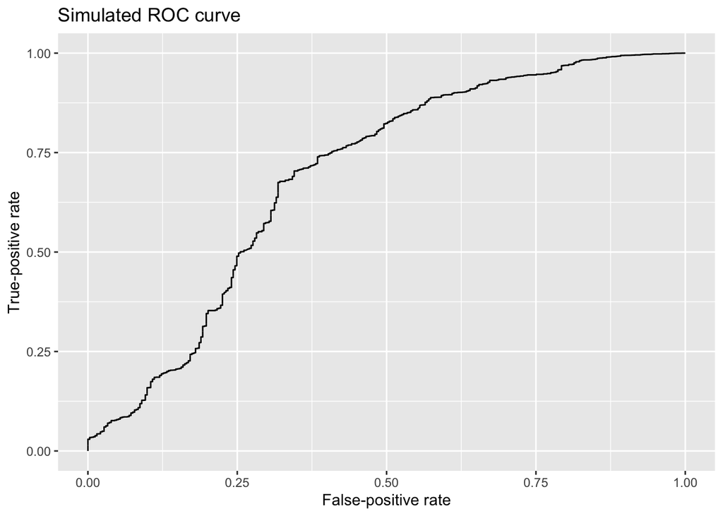

```r
predicted1 <- predict(final, newdata = testing)
roc1 = roc(response = testing$status, predictor = predicted1)
ggroc(roc1, legacy.axes = TRUE) +
  labs(x = 'False-positive rate', y = 'True-positive rate', title = 'Simulated ROC curve')
```

As we can see from the graph, the curve is increasing in both directions. This is because both False positive rate and True positive rate are increased with lower the classification threshold which classifies more items as positive. The closer the ROC curve is to the top left corner of the plot, the better the model does at classifying the data into correct categories. To quantify this, we can calculate the AUC (area under the curve) which tells us how much of the plot is located under the curve. AUC ranges in value from 0 to 1. A model whose predictions are 100% wrong has an AUC of 0; one whose predictions are 100% correct has an AUC of 1. The AUC score would be 1 in that scenario. We used the `auc()` function from the $\texttt{pROC}$ package to calculate the AUC of the model.

```r
auc(testing$status,predicted1)
```

```
## Area under the curve: 0.693
```

## Bayesian Approach

Next, we implement an alternative to the model above using a Bayesian approach. While a frequentist assumes that there are true values of the parameters of the model and computes the point estimates of the parameters, a Bayesian asserts that only data are real, and treats the model parameters as random variables whose uncertainty can be characterized by probability distributions.

### Model Fitting

To implement our Bayesian logistic model, we utilize an algorithm known as Hamiltonian Monte Carlo. In particular, we use the program Stan, via its $\texttt{R}$ interface in the $\texttt{rstanarm}$ package.

The `rstanarm` equivalent of `glm()` is `stan_glm()`, which supports every link function that `glm()` supports. With `stan_glm()`, binomial models with a logit link function can typically be fit slightly faster than the identical model with a probit link.

Note that in contrast with the Frequentist procedure, in Bayesian estimation we need to specify priors for our parameters, which permit us to incorporate existing knowledge of the parameters into our model.

In the following code, we fit a logistic model on the same training set as in the frequentist section, with specified link and the default priors for the intercept and the predictor coefficients.

```r
post <- stan_glm(status ~ loan_amount + sector + posted_yr + continent + sex,
                 data = training,
                 family = binomial(link = "logit"),
                 seed = seed,
                 refresh = 0,
                 cores=3, chains = 3,warmup = 500,iter = 1200)
```

We can save our models in a folder so that RStudio doesn’t need to go through the model fitting process every time we knit the document. Just load the models from where they are stored.

The `prior_summary()` function would allow us to see the info on priors used in this model:

```r
prior_summary(post)
```

```
## Priors for model 'post'
## ------
## Intercept (after predictors centered)
##  ~ normal(location = 0, scale = 2.5)
##
## Coefficients
##   Specified prior:
##     ~ normal(location = [0,0,0,...], scale = [2.5,2.5,2.5,...])
##   Adjusted prior:
##     ~ normal(location = [0,0,0,...], scale = [ 0.0025,15.7210, 9.1342,...])
## ------
## See help('prior_summary.stanreg') for more details
```

The default priors our model used is normal distributions with location parameter of 0 and scale parameter of 2.5, for both the intercept and coefficients.

In order to get an idea of which variables are associated with changes in the probability of repayment, we draw a caterpillar plot, which displays the posterior medians and uncertainty intervals.

We sort the predictor variables in our model `post` by their posterior medians. To do this, we extracted the `coefficient` element from `post` and converted it into a data frame which had only one column “post.coefficients”. We then sort the rows based on the value of the coefficients. Next, we extract the row names except for the intercept to pass it as the `pars` parameter in the `mcmc_intervals()` function so that it plots the 95% uncertainty intervals computed from posterior draws with all chains merged in the order of ascending median.

```r
# extract the coefficients and sort them in ascending order
coef <- data.frame(post$coefficients) %>%
  arrange(post.coefficients)

# store the variables corresponding to the coefficients as a list
order <- rownames(coef)[-1]

# plot the sorted coefficients with uncertainty interval
cate <- mcmc_intervals(as.matrix(post), pars = order, prob = 0.95, prob_outer = 1)
```

### Results

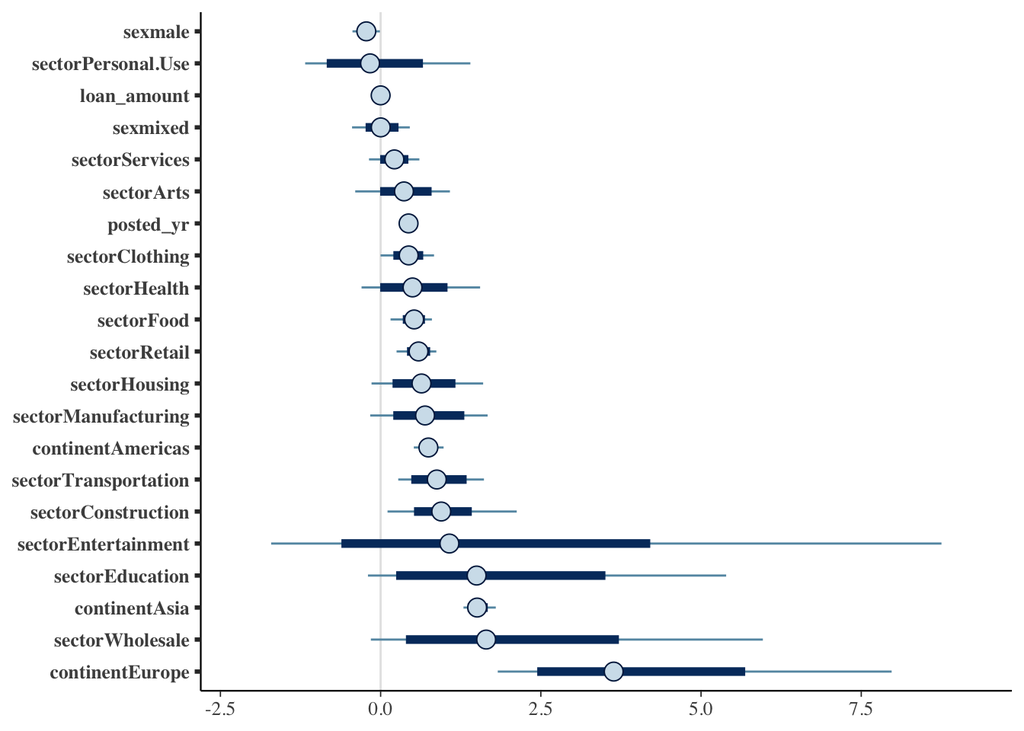

```r
coef <- coef %>%
  filter(rownames(.)!="continentOceania")
p <- data.frame(post) %>%
  select(-continentOceania)
order_new <- gsub(" ",".", rownames(coef)[-1])
cate_new <- mcmc_intervals(as.matrix(p), pars = order_new, prob = 0.95, prob_outer = 1)
cate_new
```

### Model Evaluation

```r
(loo1 <- loo(post, save_psis = TRUE, k_threshold = 0.7))
save(loo1, file = "data/loo1.RData")
```

```r
post0 <- stan_glm(status ~ 1, data = training,
                 family = binomial(link = "logit"),
                 seed = seed,
                 refresh = 0,
                 cores=3, chains = 3, warmup = 500,iter = 1200)
save(post0, file = "data/post0.RData")
```

```r
(loo0 <- loo(post0, save_psis = T))
```

```r
save(loo0, file = "data/loo0.RData")
```

```r
rstanarm::compare_models(loo0, loo1)
```

```
## Model formulas:
##  :  NULL
##  :  NULLelpd_diff        se
##     450.0      38.6
```

Below, we compute posterior predictive probabilities of the linear predictor via the `posterior_linpred()` function provided in the $\texttt{rstanarm}$ package. This function will extract posterior draws from the linear predictor. If we used a link function, then specifying the transform argument as `TRUE` will return the predictor as transformed via the inverse-link.

```r
preds <- posterior_linpred(post, transform=TRUE)
pred <- colMeans(preds)
```

We calculate these posterior predictive probabilities in order to determine the classification accuracy of our model. If the posterior probability of paying back the loan for an borrower is greater or equal to 0.5, then we would predict that observation to be a repaid loan (and similarly for less than 0.5). For each observation, we can compare the posterior prediction to the actual observed value. The proportion of times we correctly predict an individual (i.e. prediction = 0 and observation = 0 or prediction = 1 and observation = 1) is our classification accuracy.

```r
pr <- as.integer(pred >= 0.5)
round(mean(xor(pr,as.integer(training$status==0))),3)
```

```
## [1] 0.978
```

We should also evaluate the classification accuracy of our model on unseen data. This can be done by using a test dataset or via a LOOCV approach. Since we’ve talked about the former approach in the frequentist section, here we would use the latter approach to illustrate the function `E_loo()`, which uses importance weights generated from the `loo()` function. Then we would compare the accuracy for the bayesian and frequentist models on the same test data using the former approach.

```r
ploo = E_loo(preds, loo1$psis_object, type = "mean", log_ratios = -log_lik(post))$value
round(mean(xor(ploo > 0.5, as.integer(training$status == 0))), 3)
```

```
## [1] 0.978
```

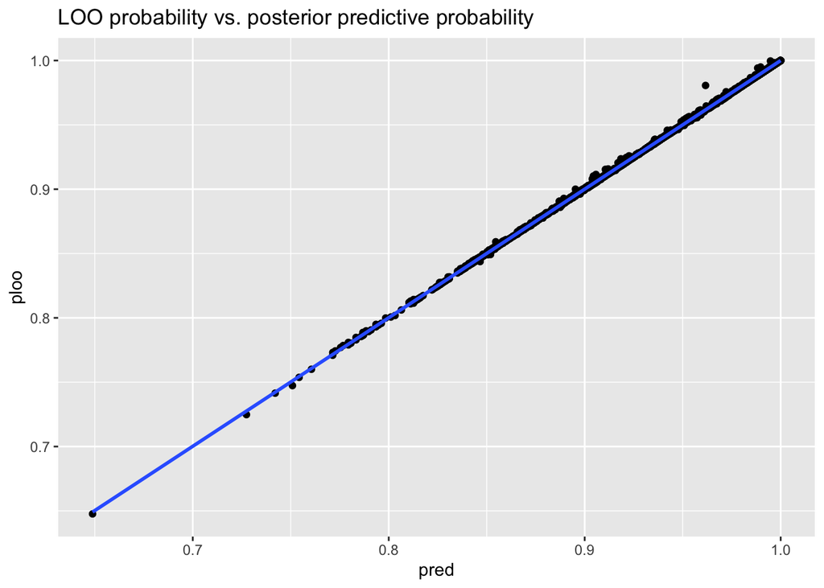

```r
qplot(pred, ploo,geom=c("point", "smooth")) +
  ggtitle("LOO probability vs. posterior predictive probability")
```

In the plot above we can see the small difference in posterior predictive probabilities and LOO probabilities.

We can again use ROC and AUC to evaluate this model. First, we need to prepare a test data set. Here we are extracting data from the original data set that are not in the sample.

```r
predicted <- predict(post, newdata=testing)
```

Here’s the ROC curve of our model on the testing data:

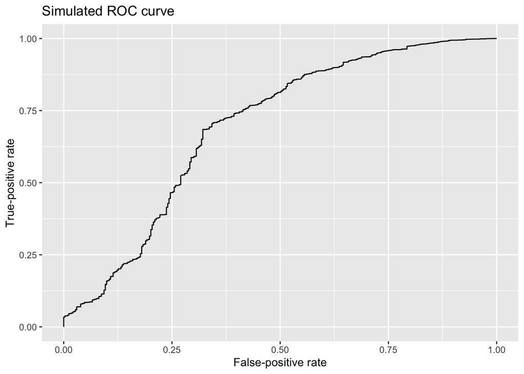

```r
roc = roc(response = testing$status, predictor = predicted)
ggroc(roc, legacy.axes = TRUE) +
  labs(x = 'False-positive rate', y = 'True-positive rate', title = 'Simulated ROC curve')
```

```r
auc(testing$status,predicted)
```

```
## Area under the curve: 0.694
```